# PartIIID

Hua Ji

4/24/2022

## Load packages

The `tidyverse` and `caret` packages are loaded below.

```r
library(tidyverse)
library(caret)
```

## Read and prepare data

```r
df_all <- readr::read_csv("final_project_train.csv", col_names = TRUE)
df_all %>%glimpse()
```

```
## Rows: 677
## Columns: 38
## $ rowid    <dbl> 1, 3, 4, 5, 8, 9, 11, 14, 15, 16, 17, 18, 19, 22, 24, 25, 27,…
## $ region   <chr> "XX", "XX", "XX", "XX", "XX", "XX", "XX", "XX", "XX", "XX", "…
## $ customer <chr> "B", "B", "B", "B", "B", "B", "B", "B", "B", "B", "B", "B", "…
## $ xb_01    <dbl> 4.000000, 1.000000, 2.000000, 2.520000, 2.548387, 3.071429, 3…
## $ xb_02    <dbl> 4, 1, 2, 11, 6, 6, 10, 12, 9, 10, 8, 10, 10, 8, 6, 10, 13, 10…
## $ xb_03    <dbl> 4, 1, 2, -6, -1, 1, -4, -4, -2, -4, -2, -2, -2, -4, 1, -4, -3…
## $ xn_01    <dbl> 3.0000000, 2.0000000, 2.0000000, 1.5333333, 0.8387097, 1.8571…
## $ xn_02    <dbl> 3, 2, 4, 9, 3, 8, 6, 10, 10, 4, 6, 8, 9, 5, 7, 12, 12, 6, 6, …
## $ xn_03    <dbl> 3, 2, 0, -3, -4, -2, -5, -6, -3, -5, -3, -6, -4, -3, 0, -5, -…
## $ xa_01    <dbl> 12.000000, 3.000000, 9.000000, 7.080000, 6.451613, 6.857143, …
## $ xa_02    <dbl> 12, 3, 9, 29, 17, 18, 24, 27, 20, 19, 15, 24, 24, 15, 14, 26,…
## $ xa_03    <dbl> 12, 3, 9, -7, -2, 2, -9, -5, -3, -3, -1, 1, -2, -3, 3, -4, -5…
## $ xb_04    <dbl> 1.3333333, 1.0000000, 1.0000000, 0.8950476, 1.2247312, 1.1857…
```

[output cut: 25 more lines]

## Resampling and performance metrics

caret will manage the training, tuning, and assessment of the models.

```r
ctrl_roc <- trainControl(method ='cv', number = 5,
                             summaryFunction = twoClassSummary,
                             classProbs = TRUE,
                             savePredictions = TRUE)

metric_data <- "ROC"
```

##1.Linear models: ##1a)All categorical and continuous inputs - linear additive features

```r
set.seed(4321)
fit_glm_1a <- train(outcome~.-response-rowid,
                    data = df_all,
                    method ="glm",
                    metric = metric_data,
                    preProcess=c("center", "scale"),
                    trControl = ctrl_roc)

fit_glm_1a
```

```
## Generalized Linear Model
##
## 677 samples
##  37 predictor
##   2 classes: 'event', 'non_event'
##
## Pre-processing: centered (43), scaled (43)
## Resampling: Cross-Validated (5 fold)
## Summary of sample sizes: 542, 542, 541, 542, 541
## Resampling results:
##
##   ROC        Sens       Spec
##   0.8320112  0.3932308  0.9309091
```

##1b)All pairwise interactions of continuous inputs, include additive categorical features

```r
set.seed(4321)
fit_glm_1b <- train(outcome~(.-response-rowid-region-customer)^2+(region+customer),
                    data = df_all,
                    method ="glm",
                    metric = metric_data,
                    preProcess=c("center", "scale"),
                    trControl = ctrl_roc)
fit_glm_1b
```

```
## Generalized Linear Model
##
## 677 samples
##  37 predictor
##   2 classes: 'event', 'non_event'
##
## Pre-processing: centered (571), scaled (571)
## Resampling: Cross-Validated (5 fold)
## Summary of sample sizes: 542, 542, 541, 542, 541
## Resampling results:
##
##   ROC        Sens       Spec
##   0.5202168  0.4966154  0.5581818
```

##1c)The 2 models selected from iiA)

```r
set.seed(4321)
fit_glm_1c <- train(outcome~(.-rowid-response-customer)*region,
                    data = df_all,
                    method ="glm",
                    metric = metric_data,
                    preProcess=c("center", "scale"),
                    trControl = ctrl_roc)
fit_glm_1c
```

```
## Generalized Linear Model
##
## 677 samples
##  37 predictor
##   2 classes: 'event', 'non_event'
##
## Pre-processing: centered (101), scaled (101)
## Resampling: Cross-Validated (5 fold)
## Summary of sample sizes: 542, 542, 541, 542, 541
## Resampling results:
##
##   ROC       Sens       Spec
##   0.738621  0.3390769  0.8654545
```

##1d)The 2 models selected from iiA)

```r
set.seed(4321)
fit_glm_1d <- train(outcome~customer*region,
                    data = df_all,
                    method ="glm",
                    metric = metric_data,
                    preProcess=c("center", "scale"),
                    trControl = ctrl_roc)
fit_glm_1d
```

```
## Generalized Linear Model
##
## 677 samples
##   2 predictor
##   2 classes: 'event', 'non_event'
##
## Pre-processing: centered (26), scaled (26)
## Resampling: Cross-Validated (5 fold)
## Summary of sample sizes: 542, 542, 541, 542, 541
## Resampling results:
##
##   ROC        Sens       Spec
##   0.5782573  0.1021538  0.9818182
```

##2.Regularized regression with Elastic net: ##2a)All pairwise interactions of continuous inputs, include additive categorical features

```r
set.seed(4321)
fit_glmnet_2a<- train(outcome~(.-response-rowid-region-customer)^2+(region+customer),
                    data = df_all,
                    method ="glmnet",
                    metric = metric_data,
                    preProcess=c("center", "scale"),
                    trControl = ctrl_roc)


fit_glmnet_2a
```

```
## glmnet
##
## 677 samples
##  37 predictor
##   2 classes: 'event', 'non_event'
##
## Pre-processing: centered (571), scaled (571)
## Resampling: Cross-Validated (5 fold)
## Summary of sample sizes: 542, 542, 541, 542, 541
## Resampling results across tuning parameters:
##
##   alpha  lambda        ROC        Sens       Spec
##   0.10   0.0003286232  0.8145007  0.2529231  0.9363636
##   0.10   0.0032862318  0.8145007  0.2529231  0.9363636
##   0.10   0.0328623182  0.8250965  0.2443077  0.9527273
##   0.55   0.0003286232  0.8004895  0.3067692  0.9145455
##   0.55   0.0032862318  0.8033119  0.3067692  0.9163636
##   0.55   0.0328623182  0.8406378  0.2132308  0.9709091
##   1.00   0.0003286232  0.7876811  0.2987692  0.9000000
##   1.00   0.0032862318  0.8118294  0.2523077  0.9200000
##   1.00   0.0328623182  0.8427441  0.1818462  0.9745455
##
## ROC was used to select the optimal model using the largest value.
## The final values used for the model were alpha = 1 and lambda = 0.03286232.
```

```r
fit_glmnet_2b<- train(outcome~.-response-rowid-region-customer,
                    data = df_all,
                    method ="glmnet",
                    metric = metric_data,
                    preProcess=c("center", "scale"),
                    trControl = ctrl_roc)


fit_glmnet_2b
```

```
## glmnet
##
## 677 samples
##  37 predictor
##   2 classes: 'event', 'non_event'
##
## Pre-processing: centered (33), scaled (33)
## Resampling: Cross-Validated (5 fold)
## Summary of sample sizes: 542, 541, 542, 542, 541
## Resampling results across tuning parameters:
##
##   alpha  lambda        ROC        Sens       Spec
##   0.10   0.0003286232  0.8181958  0.3701538  0.9418182
##   0.10   0.0032862318  0.8298601  0.3464615  0.9527273
##   0.10   0.0328623182  0.8398937  0.2596923  0.9636364
##   0.55   0.0003286232  0.8181902  0.3778462  0.9418182
##   0.55   0.0032862318  0.8312280  0.3070769  0.9509091
##   0.55   0.0328623182  0.8370993  0.2203077  0.9654545
##   1.00   0.0003286232  0.8175385  0.3778462  0.9418182
##   1.00   0.0032862318  0.8306741  0.3150769  0.9600000
##   1.00   0.0328623182  0.8356727  0.1963077  0.9745455
##
## ROC was used to select the optimal model using the largest value.
## The final values used for the model were alpha = 0.1 and lambda = 0.03286232.
```

```r
fit_glmnet_2b %>% readr::write_rds('fit_glmnet_2b.rds')
```

##2c)Interact region with continuous inputs, do not include customer

```r
set.seed(4321)
fit_glmnet_2c<- train(outcome~(.-rowid-response-customer)*region,
                    data = df_all,
                    method ="glmnet",
                    metric = metric_data,
                    preProcess=c("center", "scale"),
                    trControl = ctrl_roc)


fit_glmnet_2c
```

```
## glmnet
##
## 677 samples
##  37 predictor
##   2 classes: 'event', 'non_event'
##
## Pre-processing: centered (101), scaled (101)
## Resampling: Cross-Validated (5 fold)
## Summary of sample sizes: 542, 542, 541, 542, 541
## Resampling results across tuning parameters:
##
##   alpha  lambda        ROC        Sens       Spec
##   0.10   0.0003286232  0.7667077  0.3390769  0.9090909
##   0.10   0.0032862318  0.7928224  0.3080000  0.9400000
##   0.10   0.0328623182  0.8258573  0.2609231  0.9690909
##   0.55   0.0003286232  0.7644727  0.3470769  0.9109091
##   0.55   0.0032862318  0.8003524  0.3080000  0.9436364
##   0.55   0.0328623182  0.8288979  0.2286154  0.9672727
##   1.00   0.0003286232  0.7632000  0.3550769  0.9090909
##   1.00   0.0032862318  0.8062294  0.2846154  0.9563636
##   1.00   0.0328623182  0.8317133  0.1812308  0.9745455
##
## ROC was used to select the optimal model using the largest value.
## The final values used for the model were alpha = 1 and lambda = 0.03286232.
```

##3.Neural network

```r
set.seed(4321)
fit_nnet_3a<- train(outcome~.-response-rowid-region-customer,
                    data = df_all,
                    method ="nnet",
                    metric = metric_data,
                    preProcess=c("center", "scale"),
                    trControl = ctrl_roc,
                    trace = FALSE)

fit_nnet_3a
```

```
## Neural Network
##
## 677 samples
##  37 predictor
##   2 classes: 'event', 'non_event'
##
## Pre-processing: centered (33), scaled (33)
## Resampling: Cross-Validated (5 fold)
## Summary of sample sizes: 542, 542, 541, 542, 541
## Resampling results across tuning parameters:
##
##   size  decay  ROC        Sens       Spec
##   1     0e+00  0.7488965  0.3163077  0.9000000
##   1     1e-04  0.7589860  0.2661538  0.9254545
##   1     1e-01  0.8324336  0.4243077  0.9290909
##   3     0e+00  0.7760937  0.5058462  0.8709091
##   3     1e-04  0.7691329  0.5427692  0.8309091
##   3     1e-01  0.7946070  0.3849231  0.8836364
##   5     0e+00  0.7731734  0.5206154  0.8509091
##   5     1e-04  0.7711063  0.4273846  0.8600000
##   5     1e-01  0.7766322  0.4021538  0.8963636
##
## ROC was used to select the optimal model using the largest value.
## The final values used for the model were size = 1 and decay = 0.1.
```

##4.Random forest

```r
set.seed(4321)
fit_rf_4a<- train(outcome~.-response-rowid-region-customer,
                    data = df_all,
                    method ="rf",
                    metric = metric_data,
                    trControl = ctrl_roc,
                    importance = TRUE)

fit_rf_4a
```

```
## Random Forest
##
## 677 samples
##  37 predictor
##   2 classes: 'event', 'non_event'
##
## No pre-processing
## Resampling: Cross-Validated (5 fold)
## Summary of sample sizes: 542, 542, 541, 542, 541
## Resampling results across tuning parameters:
##
##   mtry  ROC        Sens       Spec
##    2    0.8367580  0.2043077  0.9581818
##   17    0.8252503  0.2836923  0.9345455
##   33    0.8134462  0.2913846  0.9272727
##
## ROC was used to select the optimal model using the largest value.
## The final value used for the model was mtry = 2.
```

##5.Gradient boosted tree

```r
set.seed(4321)
fit_xgb_5a<- train(outcome~.-response-rowid-region-customer,
                    data = df_all,
                    method ="xgbTree",
                    metric = metric_data,
                    trControl = ctrl_roc,
                   objective = 'reg:squarederror')
```

[output not shown]

[output not shown]

[output not shown]

[output not shown]

[output not shown]

[output not shown]

[output not shown]

[output not shown]

[output not shown]

[output not shown]

[output not shown]

[output not shown]

[output not shown]

[output not shown]

[output not shown]

[output not shown]

[output not shown]

[output not shown]

[output not shown]

[output not shown]

[output not shown]

[output not shown]

[output not shown]

[output not shown]

[output not shown]

[output not shown]

[output not shown]

[output not shown]

[output not shown]

[output not shown]

[output not shown]

[output not shown]

[output not shown]

[output not shown]

[output not shown]

[output not shown]

[output not shown]

[output not shown]

[output not shown]

[output not shown]

[output not shown]

[output not shown]

[output not shown]

[output not shown]

[output not shown]

[output not shown]

[output not shown]

[output not shown]

[output not shown]

[output not shown]

[output not shown]

[output not shown]

[output not shown]

[output not shown]

[output not shown]

[output not shown]

[output not shown]

[output not shown]

[output not shown]

[output not shown]

[output not shown]

[output not shown]

[output not shown]

[output not shown]

[output not shown]

[output not shown]

[output not shown]

[output not shown]

[output not shown]

[output not shown]

[output not shown]

[output not shown]

[output not shown]

[output not shown]

[output not shown]

[output not shown]

[output not shown]

[output not shown]

[output not shown]

[output not shown]

[output not shown]

[output not shown]

[output not shown]

[output not shown]

[output not shown]

[output not shown]

[output not shown]

[output not shown]

[output not shown]

[output not shown]

[output not shown]

[output not shown]

[output not shown]

[output not shown]

[output not shown]

[output not shown]

[output not shown]

[output not shown]

[output not shown]

[output not shown]

[output not shown]

[output not shown]

[output not shown]

[output not shown]

[output not shown]

[output not shown]

[output not shown]

[output not shown]

[output not shown]

[output not shown]

[output not shown]

[output not shown]

[output not shown]

[output not shown]

[output not shown]

[output not shown]

[output not shown]

[output not shown]

[output not shown]

[output not shown]

[output not shown]

[output not shown]

[output not shown]

[output not shown]

[output not shown]

[output not shown]

[output not shown]

[output not shown]

[output not shown]

[output not shown]

[output not shown]

[output not shown]

[output not shown]

[output not shown]

[output not shown]

[output not shown]

[output not shown]

[output not shown]

[output not shown]

[output not shown]

[output not shown]

[output not shown]

[output not shown]

[output not shown]

[output not shown]

[output not shown]

[output not shown]

[output not shown]

[output not shown]

[output not shown]

[output not shown]

[output not shown]

[output not shown]

[output not shown]

[output not shown]

[output not shown]

[output not shown]

[output not shown]

[output not shown]

[output not shown]

[output not shown]

[output not shown]

[output not shown]

[output not shown]

[output not shown]

[output not shown]

[output not shown]

[output not shown]

[output not shown]

[output not shown]

[output not shown]

[output not shown]

[output not shown]

[output not shown]

[output not shown]

[output not shown]

[output not shown]

[output not shown]

[output not shown]

[output not shown]

```r
fit_xgb_5a
```

```
## eXtreme Gradient Boosting
##
## 677 samples
##  37 predictor
##   2 classes: 'event', 'non_event'
##
## No pre-processing
## Resampling: Cross-Validated (5 fold)
## Summary of sample sizes: 542, 542, 541, 542, 541
## Resampling results across tuning parameters:
##
##   eta  max_depth  colsample_bytree  subsample  nrounds  ROC        Sens
##   0.3  1          0.6               0.50        50      0.7973455  0.2766154
##   0.3  1          0.6               0.50       100      0.7961930  0.3070769
##   0.3  1          0.6               0.50       150      0.7944699  0.3147692
##   0.3  1          0.6               0.75        50      0.8244839  0.3156923
##   0.3  1          0.6               0.75       100      0.8088336  0.2916923
##   0.3  1          0.6               0.75       150      0.8075105  0.2913846
##   0.3  1          0.6               1.00        50      0.8307371  0.2132308
##   0.3  1          0.6               1.00       100      0.8306587  0.2673846
##   0.3  1          0.6               1.00       150      0.8244811  0.2910769
##   0.3  1          0.8               0.50        50      0.8158601  0.2830769
##   0.3  1          0.8               0.50       100      0.8034238  0.2750769
##   0.3  1          0.8               0.50       150      0.7955664  0.2987692
##   0.3  1          0.8               0.75        50      0.8275413  0.2600000
##   0.3  1          0.8               0.75       100      0.8269846  0.2673846
##   0.3  1          0.8               0.75       150      0.8202266  0.2750769
##   0.3  1          0.8               1.00        50      0.8293664  0.2366154
##   0.3  1          0.8               1.00       100      0.8261455  0.2833846
##   0.3  1          0.8               1.00       150      0.8239161  0.2913846
##   0.3  2          0.6               0.50        50      0.7847552  0.2910769
##   0.3  2          0.6               0.50       100      0.7544503  0.2981538
##   0.3  2          0.6               0.50       150      0.7462965  0.3227692
##   0.3  2          0.6               0.75        50      0.7730797  0.2830769
##   0.3  2          0.6               0.75       100      0.7485510  0.3218462
##   0.3  2          0.6               0.75       150      0.7244671  0.3215385
##   0.3  2          0.6               1.00        50      0.7966462  0.2123077
##   0.3  2          0.6               1.00       100      0.7730238  0.2283077
##   0.3  2          0.6               1.00       150      0.7611916  0.2206154
##   0.3  2          0.8               0.50        50      0.7840112  0.2984615
```

[output cut: 182 more lines]

```
##   0.8709091
##   0.8836364
##   0.8854545
##   0.8890909
##   0.9090909
##   0.8927273
##   0.8981818
##
## Tuning parameter 'gamma' was held constant at a value of 0
## Tuning
##  parameter 'min_child_weight' was held constant at a value of 1
## ROC was used to select the optimal model using the largest value.
## The final values used for the model were nrounds = 50, max_depth = 1, eta
##  = 0.4, gamma = 0, colsample_bytree = 0.6, min_child_weight = 1 and subsample
##  = 1.
```

```r
set.seed(4321)
fit_svm_6a<- train(outcome~.-response-rowid-region-customer,
                    data = df_all,
                    method ="svmRadial",
                    metric = metric_data,
                    preProcess=c("center","scale"),
                    trControl = ctrl_roc)

fit_svm_6a
```

```
## Support Vector Machines with Radial Basis Function Kernel
##
## 677 samples
##  37 predictor
##   2 classes: 'event', 'non_event'
##
## Pre-processing: centered (33), scaled (33)
## Resampling: Cross-Validated (5 fold)
## Summary of sample sizes: 542, 542, 541, 542, 541
## Resampling results across tuning parameters:
##
##   C     ROC        Sens       Spec
##   0.25  0.7832056  0.1661538  0.9636364
##   0.50  0.7829930  0.1815385  0.9600000
##   1.00  0.7837371  0.1975385  0.9618182
##
## Tuning parameter 'sigma' was held constant at a value of 0.03030606
## ROC was used to select the optimal model using the largest value.
## The final values used for the model were sigma = 0.03030606 and C = 1.
```

```r
set.seed(4321)
fit_rpart_7a<- train(outcome~.-response-rowid-region-customer,
                    data = df_all,
                    method ="rpart",
                    metric = metric_data,
                    trControl = ctrl_roc)

fit_rpart_7a
```

```
## CART
##
## 677 samples
##  37 predictor
##   2 classes: 'event', 'non_event'
##
## No pre-processing
## Resampling: Cross-Validated (5 fold)
## Summary of sample sizes: 542, 542, 541, 542, 541
## Resampling results across tuning parameters:
##
##   cp          ROC        Sens       Spec
##   0.03149606  0.6988601  0.2353846  0.9181818
##   0.04724409  0.6761287  0.1941538  0.9309091
##   0.06299213  0.6798014  0.2181538  0.9345455
##
## ROC was used to select the optimal model using the largest value.
## The final value used for the model was cp = 0.03149606.
```

###Compare models ##Compile the resampling results together.

```r
my_results <- resamples(list(LM_1 = fit_glm_1a,
                             LM_3 = fit_glm_1c,
                             LM_4 = fit_glm_1d,
                             ENET_1 = fit_glmnet_2a,
                             ENET_2 = fit_glmnet_2b,
                             ENET_3 = fit_glmnet_2c,
                             NNET = fit_nnet_3a,
                             RF = fit_rf_4a,
                             XGB = fit_xgb_5a,
                             SVM = fit_svm_6a,
                             CART = fit_rpart_7a))
```

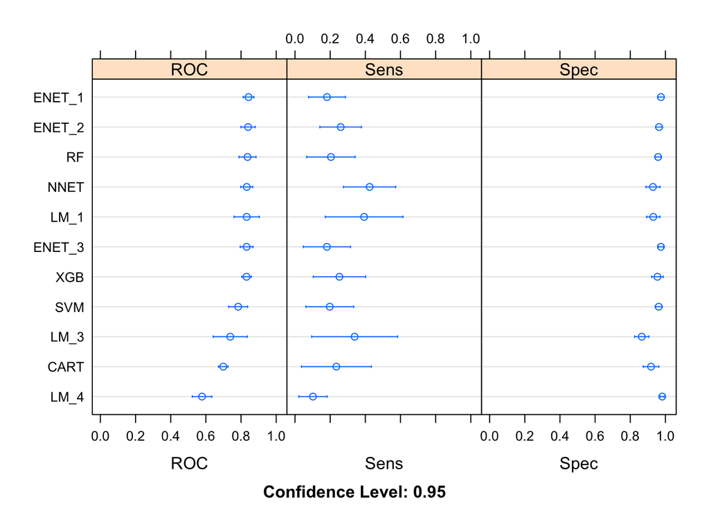

```r
dotplot(my_results)
```

From ROC, Sensitivity, and Specificity, we can choose Enet_1,Enet_1,RF,NNET as the top four best model. Now let’s extracts the hold-out set predictions associated with the best tuning parameter values for 4 of the models trained,the elastic net, the neural network, and the random forest.

```r
model_pred_results <- fit_rf_4a$pred %>% tibble::as_tibble() %>%
  filter(mtry == fit_rf_4a$bestTune$mtry) %>%
  select(pred, obs, event, non_event, rowIndex, Resample) %>%
  mutate(model_name = "RF") %>%
  bind_rows(fit_glmnet_2a$pred %>% tibble::as_tibble() %>%
              filter(alpha == fit_glmnet_2a$bestTune$alpha,
                     lambda == fit_glmnet_2a$bestTune$lambda) %>%
              select(pred, obs,event, non_event, rowIndex, Resample) %>%
              mutate(model_name = "ENET_1")) %>%
  bind_rows(fit_glmnet_2b$pred %>% tibble::as_tibble() %>%
              filter(alpha == fit_glmnet_2b$bestTune$alpha,
                     lambda == fit_glmnet_2b$bestTune$lambda) %>%
              select(pred, obs, event, non_event, rowIndex, Resample) %>%
              mutate(model_name = "ENET_2")) %>%
  bind_rows(fit_nnet_3a$pred %>% tibble::as_tibble() %>%
              filter(size == fit_nnet_3a$bestTune$size,
                     decay == fit_nnet_3a$bestTune$decay) %>%
              select(pred, obs, event, non_event, rowIndex, Resample) %>%
              mutate(model_name = "NNET"))
```

The first few rows of the `model_pred_results` object are displayed for you in the code chunk below.

```r
model_pred_results %>% head()
```

```
## # A tibble: 6 × 7
##   pred      obs       event non_event rowIndex Resample model_name
##   <fct>     <fct>     <dbl>     <dbl>    <int> <chr>    <chr>
## 1 non_event non_event 0.04      0.96         1 Fold1    RF
## 2 non_event non_event 0.368     0.632        5 Fold1    RF
## 3 non_event non_event 0.45      0.55        11 Fold1    RF
## 4 non_event non_event 0.196     0.804       13 Fold1    RF
## 5 non_event non_event 0.406     0.594       23 Fold1    RF
## 6 non_event non_event 0.1       0.9         28 Fold1    RF
```

```r
library(yardstick)
```

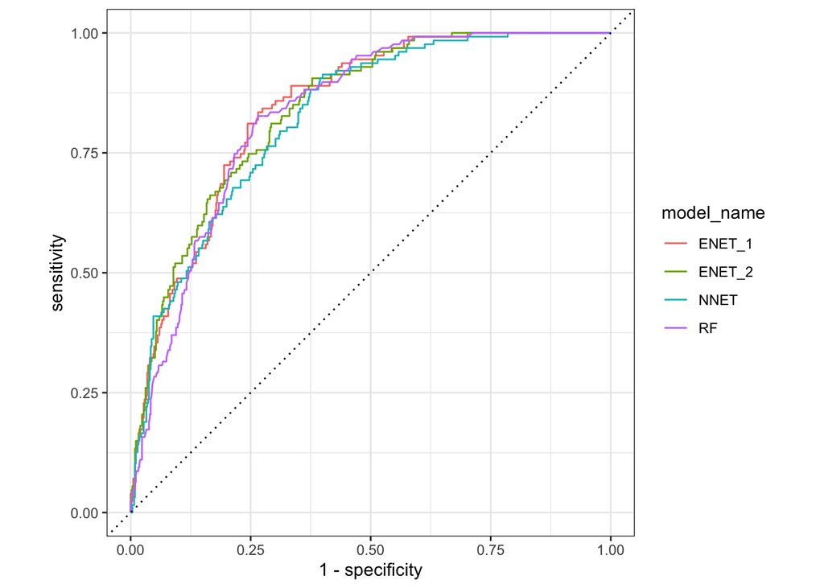

```r
###
model_pred_results%>% group_by(model_name)%>% roc_curve(obs,event)%>% autoplot()
```

According to the the AUC, we also can get the conclusion that the ENET_1 is the best model in classification.